# Adaptive Trial Design for the RAS-Inhibitor Era: Combinations, Resistance, and Biomarker-Guided Therapy

Naim Rashid, PhD

Department of Biostatistics · Lineberger Comprehensive Cancer Center · UNC

NCI GI SPORE Meeting · June 2026

## Today’s argument

> **New RAS therapies in PDAC need new kinds of trials.**

We know how to **optimize combination doses**.

We know how to **adapt trials to emerging resistance**.

The challenge is making these designs practical enough to launch.

# The clinical case

*Why combinations, and why now?*

## The RAS revolution has arrived for PDAC

A major survival signal from direct RAS inhibition in PDAC.

- **RASolute 302** (2L mPDAC, *NEJM* 2026)<sup>1</sup>:
  - **Median OS: 13.2 vs 6.7 months**
  - **HR 0.40, 60% reduction in risk of death** (p < 0.0001)
- Daraxonrasib (RMC-6236), oral, multi-selective RAS(ON) inhibitor
- ASCO 2026 Plenary, May 31 (Wolpin)

O’Reilly et al., *NEJM* 2026 (RASolute 302) · ASCO Plenary Abstr LBA5

[figure not shown]

## …but monotherapy has a narrow tolerability margin

RMC-6236-001 (PDAC cohort, *NEJM* 2026)<sup>2</sup>

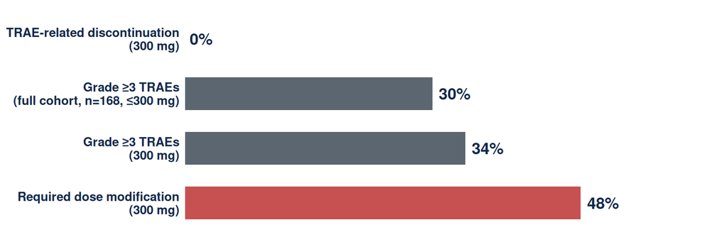

**48% of monotherapy patients require dose modification at 300 mg**, a strong signal of **limited tolerability margin**. Combinations can layer **overlapping, non-additive** toxicity that single-agent data don’t reliably predict, which is why the combination needs its own dose-finding.

Wolpin et al., *NEJM* 2026 (RMC-6236-001 PDAC cohort)

## Biomarker-driven combinations are the next move

- Daraxonrasib drives **RTK pathway activation** on PDAC cells, through cell-surface upregulation<sup>3</sup> and recurrent genomic alterations<sup>4</sup>, the mechanistic case for biomarker-driven, resistance-preemptive combinations
- **1L combination cohort** (daraxonrasib **200 mg** + GnP, n=40)<sup>5</sup>:
  - ORR: **58%** · DCR: **90%** · 6-mo PFS: **84%** · 6-mo OS: **90%**

[figure not shown]

The same adaptation that creates resistance may create a therapeutic vulnerability.

Zhuang et al., *Cancer Res* 2026 (AACR RAS) · Aguirre et al., *Cancer Discov* 2024 · Wolpin et al., AACR 2026 LB407

# The dose-finding problem

*Why MTD only may not be best for RAS combinations, and what replaces it.*

## Why combinations break the rules you grew up on

- **Rivière’s 2015 review of 162 pre-2015 combination Phase I trials: 88% used 3+3** even when both drugs were escalated<sup>6,7</sup>.
- **Why 3+3 doesn’t fit combinations.** Built for single-agent cytotoxics<sup>8</sup>, it assumes monotonic dose-toxicity, Cycle-1-observable DLTs, and a single dose dimension, combinations strain all three (e.g., **immune toxicities often emerge weeks later, outside the DLT window**).
- **The two-drug dose map is rarely built.** In practice: pick A’s dose, fix it, add B. The joint surface goes unexplored for two reasons: **regulatory anchoring** of approved-agent doses, and the **calibration burden** of dual-agent designs.

*Two-drug dose map: how efficacy and toxicity change across every (A, B) dose pair, not just along one drug’s axis.*

Le Tourneau et al., *JNCI* 2009 · Rivière et al., *Ann Oncol* 2015

## The Amgen case: sotorasib + pembrolizumab

A real-world example of why combination toxicity can surprise us.

**Same sponsor, two different designs:**

- **Monotherapy (CodeBreaK 100):** Bayesian model-based, single-agent surface
- **Combination:** IO dose fixed, only sotorasib varied, joint surface never modeled

The defining toxicity:

- Severe **immune-mediated** hepatotoxicity, not predictable from the single agent
- **88%** of Grade 3-4 events outside the Cycle 1 DLT window<sup>9</sup>

**What MTD-only dose-finding was never built to handle, all at once:** joint surface unsearched, non-additive toxicity, late-onset toxicity.

Hong et al., *NEJM* 2020 (CodeBreaK 100) · Li et al., *JTO* 2022 (WCLC OA03.06)

## Why MTD-only dose-finding doesn’t fit targeted agents and immunotherapies

[figure not shown]

- **Pembrolizumab**, efficacy plateaus at the lowest dose tested; MTD never reached<sup>10</sup>
- **CAR-T**, efficacy *rises then falls* (umbrella); high doses drive severe CRS/ICANS, not benefit
- **A RAS combination spans both shapes.** Neither rewards titrating to toxicity.

## The cost of MTD-only dose-finding

- **Sotorasib** (KRAS G12C, first-in-class, approved 2021)<sup>11</sup>:
  - 960 mg selected as the **highest dose tested**, no DLTs, a more-is-better default, not an MTD
- **More than 40% of patients** in small-molecule registrational trials require dose reductions or interruptions<sup>12</sup>

240 mg ≈ 960 mg on PFS

FDA-required post-marketing comparison: similar PFS at **one-quarter** the exposure<sup>13</sup>.

*Same drug class as daraxonrasib.*

Hong et al., *NEJM* 2020 (CodeBreaK 100) · Hochmair et al., *Eur J Cancer* 2024 · FDA–AACR, *Clin Cancer Res* 2025

## Project Optimus: the regulatory ground has shifted

- FDA final guidance, 2024<sup>14</sup>
- Sponsors must **study more than one dose** and justify on efficacy and safety
- **Maximum Tolerated Dose → Optimal Biological Dose (OBD)**, a dose optimized on benefit-risk

**OBD** = the dose that **optimizes the efficacy–toxicity trade-off**, chosen by weighing the value of a response against the cost of toxicity, not by escalating until DLTs cap the dose<sup>15,16</sup>.

**Thall et al.** *Clin Trials* 2024: conventional Phase I designs cannot reliably identify safe and effective doses<sup>17</sup>.

FDA Guidance for Industry, 2024 (Project Optimus) · Thall et al., *Clin Trials* 2024

## How OBD selection actually works

**Instead of escalating until toxicity, choose the dose with the best benefit-risk profile.**

*“How much efficacy would you trade for additional toxicity?”*

The team writes that utility table down up front. The design then searches inside the safe envelope for the dose that **maximizes benefit-risk**, not toxicity.

**Elicited utility table** (Zhou 2019 framework)<sup>15</sup>:

|  | Tox | No tox |
| --- | --- | --- |
| **Response** | 40 | **100** |
| No response | **0** | 60 |

*A tolerated non-response (60) is preferred to a toxic response (40).*

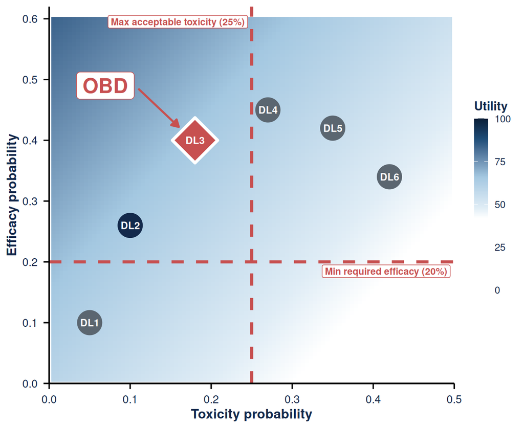

**OBD** = admissible dose (inside red lines) with the highest utility.

Liu & Yuan 2015 · Zhou, Lee & Yuan 2019 (U-BOIN) · FDA Optimus Guidance

## Combination dose selection in RAS is harder

**Combinations make MTD-only dose-finding worse on every axis.**

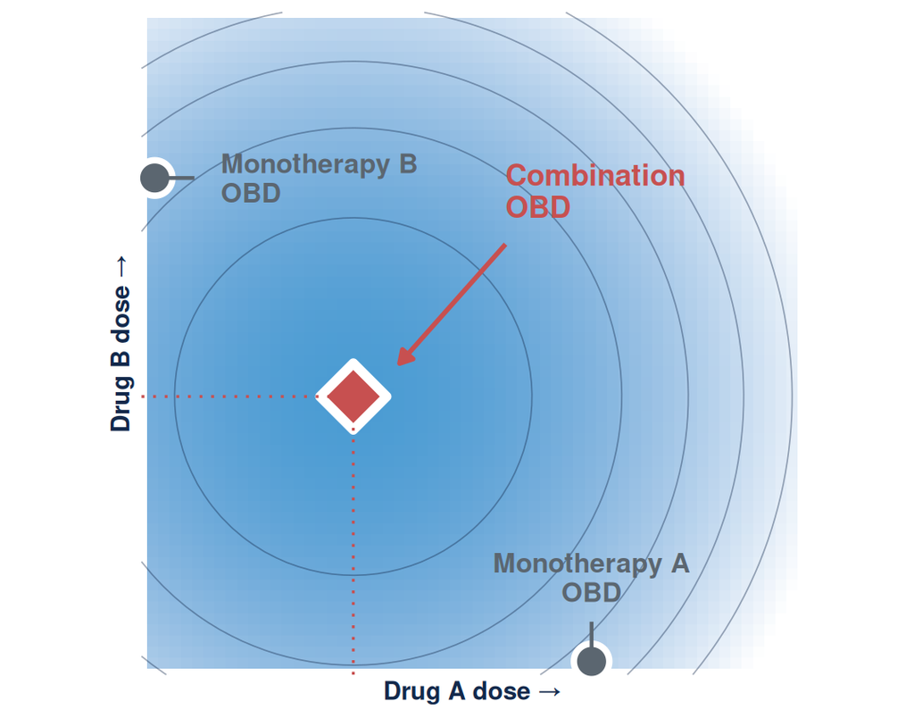

Conceptual schematic of the benefit-risk surface. The combination OBD sits below both single-agent OBDs; single-agent data alone cannot reconstruct the contour.

- The combination OBD can sit **below both single-agent OBDs**
- Single-agent data **cannot reconstruct** the joint surface
- For RAS, the **tolerability margin is already limited** at the monotherapy dose

**Fix what you know. Search what you don’t.**

RMC-GI-102 (daraxonrasib + GnP) fixed daraxonrasib at 200 mg without searching the joint surface<sup>5</sup>.

Hong et al., *NEJM* 2020 · Wolpin et al., *NEJM* 2026 (RMC-6236-001)<sup>2,11</sup>

## Finding the right erlotinib dose in basal-like PDAC

- **Clinical question.** Could *lower*-dose erlotinib work *better* than full-dose erlotinib in basal-like PDAC, when combined with GnP?
- **Design.** First find the safe dose range, then choose the dose with the best response/toxicity trade-off<sup>15,18</sup>.
- **Why it matters.** This is an OBD-below-MTD question; 3+3 cannot answer it.

**Trial:** LCCC2220-DCT (Somasundaram, PI), basal-like PDAC by PurIST<sup>19</sup> · combination erlotinib + biweekly GnP · OBD-below-MTD hypothesized from prior data<sup>20</sup> · **up to 52 patients; ~28 expected at the OBD.**

Rashid et al., *Clin Cancer Res* 2020 (PurIST) · Cohen et al., *Cancer Chemo Pharm* 2016 · Liu & Yuan 2015 · Zhou, Lee & Yuan 2019 (U-BOIN)

[figure not shown]

# Resistance is the next problem

*Phase 2 onward:* *each patient is a moving target*

## Resistance is a dynamic process

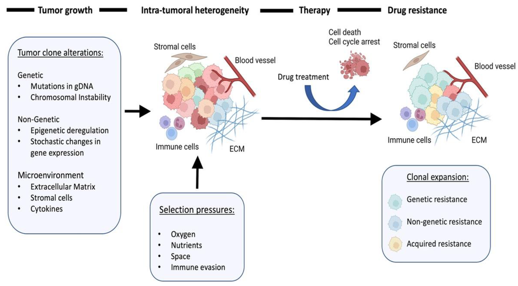

Adapted from Karagiannis & Rampias, *Cancers* 2022<sup>21</sup>.

**Resistance mechanisms emerge under RAS-inhibitor pressure**

**Daraxonrasib monotherapy in mPDAC** (n=44, paired ctDNA): **59% show RAS-pathway resistance at progression, KRAS amplification in 36%**<sup>22</sup>

## Why classical trial designs miss resistance

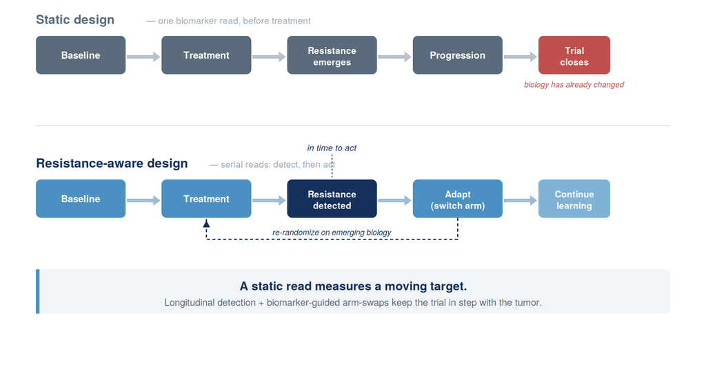

Awad et al., *NEJM* 2021 · Aguirre et al., *Cancer Discov* 2024

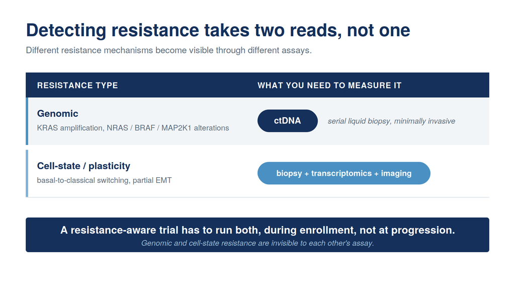

Awad et al., *NEJM* 2021 · Aguirre et al., *Cancer Discov* 2024

## ADAPT / EVOLVE: what a resistance-aware trial looks like

ARPA-H’s resistance-tracking template.

ARPA-H’s flagship adaptive resistance-monitoring platform.

- Longitudinal resistance detection
- Biomarker-guided adaptation
- Adaptive arm-swaps on emerging biology

ARPA-H **ADAPT** → **EVOLVE** (UNC-led; Carey MPI, Rashid MPI). **Enrolling.**

[figure not shown]

ARPA-H ADAPT, current state (top) vs dynamic-biomarker state (bottom).

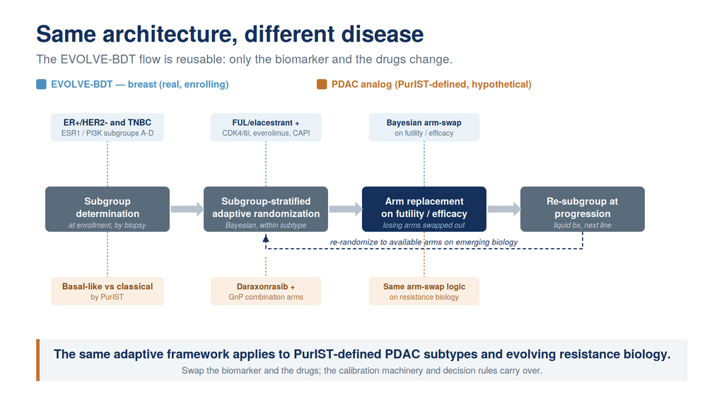

## What it would take to actually run these trials

Four things any such trial has to do at once.

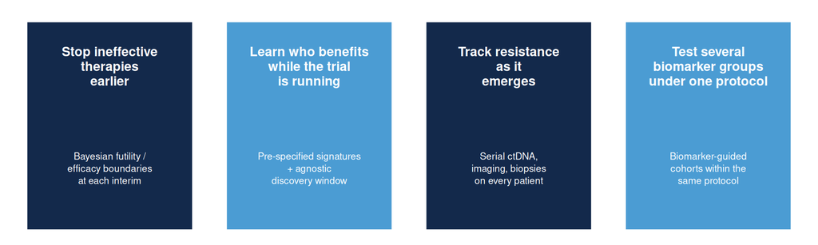

Everything I’ve just described already exists statistically. **So why don’t we see these trials everywhere?**

# Putting these into practice

## Why don’t we see more of these trials?

Funding, accrual, and biopsy logistics are real. **But the barrier we can actually remove is calibration.**

Before an adaptive trial can open, **thousands of simulations** are needed to prove it is safe, efficient, and scientifically reliable. *That process, not the design itself, is often the bottleneck.*

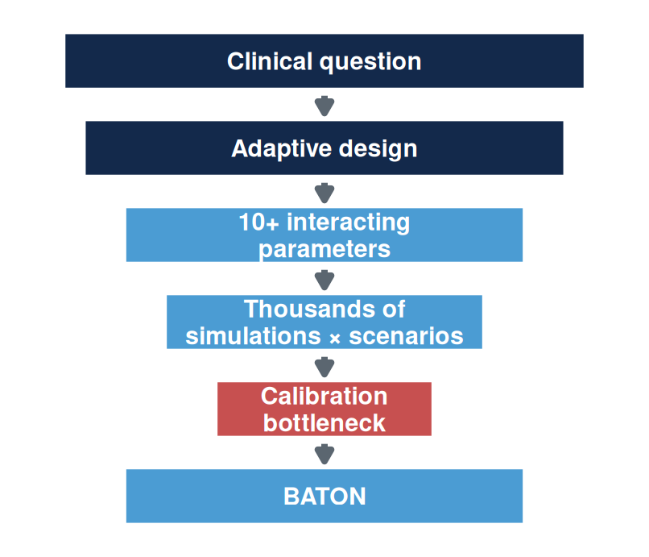

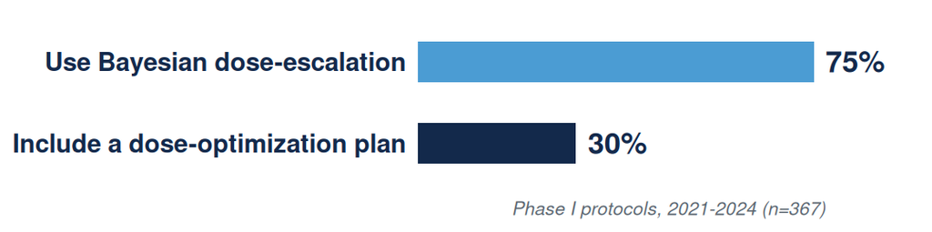

The **methodology** is being adopted; the **dose-optimization deliverable** is lagging. That gap is what calibration cost looks like.

**Our group: several months per design, hand-tuning quickly becomes infeasible.**

FDA–AACR Project Optimus impact review, *JCO Onc Adv* 2025 (367 Phase I protocols)

## Calibration has to hit four goals at once

A trial design has to clear **FDA Type I and Power**, **minimize patients**, **stop bad arms early**, and **accelerate good arms**, all four at once.

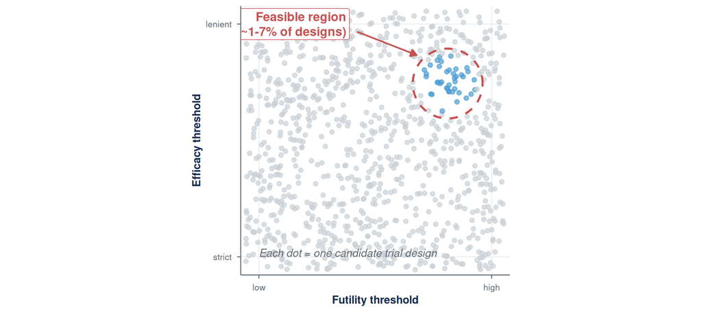

Out of thousands of plausible designs, only a small fraction satisfies all four, and you cannot find it by hand.

“We knew what trial to run.

We needed a way to make it launchable.”

## BATON: a way to make adaptive trials launchable

BATON automatically searches thousands of candidate designs and identifies those that meet FDA, efficiency, and scientific goals.

**BATON** = **B**ayesian **A**daptive **T**rial **O**ptimizatio**N**<sup>23</sup>

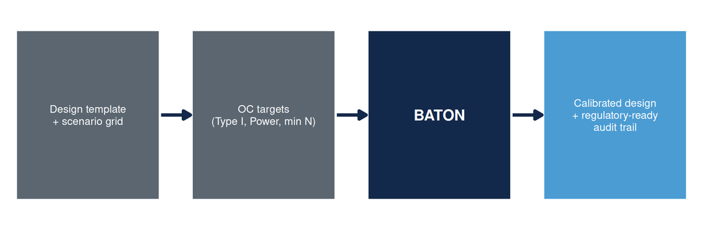

You bring the clinical inputs. BATON returns the calibration.

## Why BATON beats grid search and manual tuning

The problem: thousands of candidate designs, a tiny feasible region. The question is how you search.

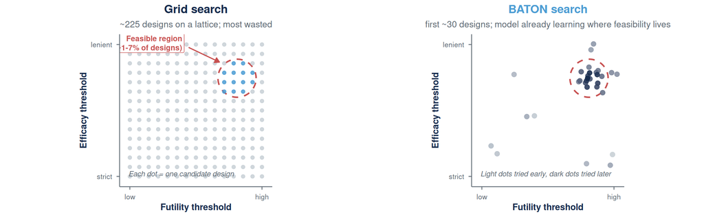

**After each design, BATON builds a model of which parameters meet your targets**, then picks the next design where the model says feasible designs likely live. Grid ignores prior results; manual tuning does this by intuition.

## A BATON-calibrated design hits all four goals, for PANGEA Phase II

[figure not shown]

**Far fewer evaluations than grid search**, finds feasible designs grid search often misses entirely.

## What this means for a PDAC patient

Mr. Hernandez, 62, mPDAC, basal-like by PurIST, progressed on 1L GnP.

Traditional fixed Phase II

- All **76 patients** enrolled before any look
- Drug effect discovered only at study end
- **~36+ months** to read out

PANGEA Phase II (BATON-calibrated)

- **78% chance** of early futility stop **when the drug is inactive**
- Average patients enrolled: **~53** if inactive / **~58** if active
- **27.3 months** expected duration

**Sooner answers. Fewer patients exposed to ineffective therapy. No sacrifice in statistical rigor.**

## PANGEA Phase II: calibrated by BATON

BATON identified a design that preserves power, controls false positives, and allows early stopping when erlotinib isn’t helping.

Achieved operating characteristics

| Metric | Value |
| --- | --- |
| Power | **82.2%** |
| Type I error | 7.0% |
| Max N | **76** (82 accrual w/ buffer) |
| Expected N under H₀ | 53.0 |
| Expected N under H₁ | 58.1 |
| Pr(early futility stop \| H₀) | **77.9%** |
| Pr(early efficacy stop \| H₁) | **81.4%** |
| Expected duration | 27.3 mo |

H₀ = drug inactive · H₁ = drug active (HR 0.58). *Read as: 78% early-stop when inactive; 81% early-stop when it works.*

**Why max N = 76, not lower:** caps set too low silently suppress early-efficacy stopping. BATON surfaced the trade-off curve; we chose 76 to preserve it.

Von Hoff et al., *NEJM* 2013 (MPACT) · Young et al., 2026 (BATON manuscript)

## What becomes possible

BATON calibrates **aggressive**, **conservative**, or **balanced** designs, and ports across GI applications:

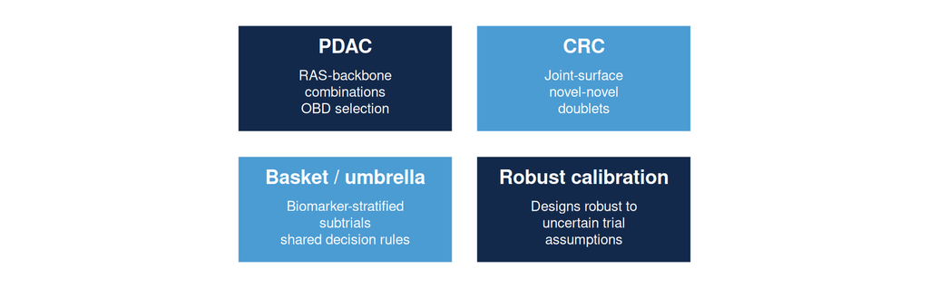

BATON is the infrastructure that makes adaptive trial design routine across the GI portfolio.

Adaptive, resistance-aware trials as the routine standard across GI, not the exception.

## Take-home

1. **The RAS era needs new kinds of trials**, biomarker-guided, dose-optimized, resistance-aware.
2. **The methods exist.** Bayesian adaptive designs can handle dose optimization, biomarker guidance, and resistance-aware adaptation.
3. **BATON removes one of the major barriers preventing these designs from reaching patients.**

## Acknowledgments

**Clinical collaborators**

- Jen Jen Yeh (UNC Surgery, SToP SPORE PI · PDAC collaborator)
- Ashwin Somasundaram (PANGEA PI)

**EVOLVE MPI team**

- Lisa Carey (UNC) · Charles Perou (UNC) · Ian Krop, Eric Winer (Yale) · Antonio Wolff (Hopkins)

**EVOLVE Statistical Working Group**

- Susan Hilsenbeck (Baylor) · Nabihah Tayob (DFCI) · Ruizhe Chen (Hopkins)

**Rashid Lab**

- **Amber Young**, Tyler Humpherys, Dinelka Nanayakkara, Jialiu Xie, Andrew Walther

**Funding**

- **NCI P50-CA257911**, UNC **SToP** SPORE
- ARPA-H 140D042590009
- DOD HT9425241103100121
- NCI U01-CA274298

Der & Yeh, *NEJM* 2026 (editorial)

## References

1.

Eileen M. O’Reilly, Zev A. Wainberg, Andrew E. Hendifar, Mitesh J. Borad, Filippo Pietrantonio, Shubham Pant, Pascal Hammel, Chiara Cremolini, Gulam A. Manji, Paul E. Oberstein, Ignacio Garrido-Laguna, Christoph Springfeld, Nilofer S. Azad, Makoto Ueno, Stephen Y. Chui, Ying Zhang, Hina Patel, Yeonju Lee, Zeena Salman, Brian M. Wolpin, RASolute 302 Trial Investigators. Daraxonrasib or chemotherapy in previously treated metastatic pancreatic cancer. New England Journal of Medicine. 2026. doi:10.1056/NEJMoa2605555

2.

Brian M. Wolpin, others. Daraxonrasib in previously treated advanced RAS-mutated pancreatic cancer. New England Journal of Medicine. 2026;394(18):1790–802. doi:10.1056/NEJMoa2505783

3.

Yongxian Zhuang, others. The RAS(ON) multi-selective inhibitor daraxonrasib (RMC-6236) induces receptor tyrosine kinase cell-surface expression on pancreatic cancer cells. Cancer Research. 2026;86(5_Suppl_1):PR009. doi:10.1158/1538-7445.RASONCOTHER26-PR009

4.

others. Mechanisms of resistance to oncogenic KRAS inhibition in pancreatic cancer. Cancer Discovery. 2024;14(11):2135–61. doi:10.1158/2159-8290.CD-24-0177

5.

Brian M. Wolpin, Benjamin L. Musher, Gulam A. Manji, others. Daraxonrasib plus chemotherapy as first-line treatment for patients with metastatic pancreatic adenocarcinoma. AACR Annual Meeting 2026, Abstr LB407 (RMC-GI-102, NCT06445062); 2026.

6.

Marie-Karelle Rivière, Christophe Le Tourneau, Xavier Paoletti, Frédéric Dubois, Sarah Zohar. Designs of drug-combination phase I trials in oncology: A systematic review of the literature. Annals of Oncology. 2015;26(4):669–74. doi:10.1093/annonc/mdu516

7.

Jennifer A. Harrington, Graham M. Wheeler, Michael J. Sweeting, Adrian P. Mander, Duncan I. Jodrell. Adaptive designs for dual-agent phase I dose-escalation studies. Nature Reviews Clinical Oncology. 2013;10(5):277–88. doi:10.1038/nrclinonc.2013.35

8.

Christophe Le Tourneau, J. Jack Lee, Lillian L. Siu. Dose escalation methods in phase I cancer clinical trials. Journal of the National Cancer Institute. 2009;101(10):708–20. doi:10.1093/jnci/djp079

9.

Bob T. Li, Gerald S. Falchook, Gregory A. Durm, others. OA03.06 CodeBreaK 100/101: First report of safety/efficacy of sotorasib in combination with pembrolizumab or atezolizumab in advanced KRAS p.G12C NSCLC. Journal of Thoracic Oncology. 2022;17(9):S10–1.

10.

Amita Patnaik, others. Phase I study of pembrolizumab (MK-3475; anti–PD-1 monoclonal antibody) in patients with advanced solid tumors. Clinical Cancer Research. 2015;21(19):4286–93. doi:10.1158/1078-0432.CCR-14-2607

11.

David S. Hong, others. KRAS<sup>G12C</sup> inhibition with sotorasib in advanced solid tumors. New England Journal of Medicine. 2020;383(13):1207–17. doi:10.1056/NEJMoa1917239

12.

Hao Zhu, Alex N. Phipps, Ying Yuan, Brad A. Davidson, Stacy S. Shord, Jiang Liu, Patricia M. LoRusso. FDA–AACR strategies for optimizing dosages for oncology drug products: Selecting dosages for first-in-human trials. Clinical Cancer Research. 2025;31(23):4872–81. doi:10.1158/1078-0432.CCR-25-0095

13.

Maximilian J. Hochmair, Karim Vermaelen, Giannis Mountzios, others. Sotorasib (960 mg or 240 mg) once daily in patients with previously treated KRAS G12C-mutated advanced NSCLC. European Journal of Cancer. 2024;208:114204. doi:10.1016/j.ejca.2024.114204

14.

U.S. Food and Drug Administration. Optimizing the dosage of human prescription drugs and biological products for the treatment of oncologic diseases. Guidance for Industry (final); 2024.

15.

Yanhong Zhou, J. Jack Lee, Ying Yuan. A utility-based bayesian optimal interval (U-BOIN) phase I/II design to identify the optimal biological dose for targeted and immune therapies. Statistics in Medicine. 2019;38(28):5299–316.

16.

Ruitao Lin, Yanhong Zhou, Fangrong Yan, Daniel Li, Ying Yuan. BOIN12: Bayesian optimal interval phase I/II trial design for utility-based dose finding in immunotherapy and targeted therapies. JCO Precision Oncology. 2020;4:1393–402.

17.

Peter F. Thall, Elizabeth Garrett-Mayer, Nolan A. Wages, Susan Halabi, Ying Kuen Cheung. Current issues in dose-finding designs: A response to the US FDA oncology center of excellence project optimus. Clinical Trials. 2024;21(3):267–72.

18.

Suyu Liu, Ying Yuan. Bayesian optimal interval designs for phase I clinical trials. Journal of the Royal Statistical Society: Series C (Applied Statistics). 2015;64(3):507–23.

19.

Naim U. Rashid, Xianlu L. Peng, Chong Jin, Richard A. Moffitt, Keith E. Volmar, Brian A. Belt, Roheena Z. Panni, Timothy M. Nywening, Stephen G. Herrera, Kathleen J. Moore, Sharon G. Hennessey, Ashley B. Morrison, Ryan Kawalerski, Apoorve Nayyar, Albert E. Chang, Bradley Schmidt, Hong Jin Kim, David C. Linehan, Jen Jen Yeh. Purity independent subtyping of tumors (PurIST): A clinically robust, single-sample classifier for tumor subtyping in pancreatic cancer. Clinical Cancer Research. 2020;26(1):82–92. doi:10.1158/1078-0432.CCR-19-1467

20.

Steven J. Cohen, others. A phase 1b study of erlotinib in combination with gemcitabine and nab-paclitaxel in patients with previously untreated advanced pancreatic cancer. Cancer Chemotherapy and Pharmacology. 2016;77(4):693–701.

21.

Dimitris Karagiannis, Theodoros Rampias. Cancer evolution in precision medicine era. Cancers (Basel). 2022;14(8):1885. doi:10.3390/cancers14081885

22.

Ida Aronchik, others. Mechanisms of resistance to the RAS(ON) multi-selective inhibitor daraxonrasib in pancreatic cancer. ENA Symposium 2025, Revolution Medicines poster; 2025.

23.

Amber M. Young, others. BATON: Constrained Bayesian optimization for calibrating adaptive trials. 2026.

24.

Daniel D. Von Hoff, others. Increased survival in pancreatic cancer with nab-paclitaxel plus gemcitabine. New England Journal of Medicine. 2013;369(18):1691–703. doi:10.1056/NEJMoa1304369